# ESM 206 Lab 5

Allison Horst, edited by ACG

10/25/2019

### Counts, uncounts, t-tests, lubridate

#### Lab 5 objectives:

- Get counts of grouped observations using `count()`
- Perform one and two sample t-tests with `t.test()`
- Parse dates with `lubridate`
- Build a `geom_tile()` heatmap

Set-up: Students should Fork & Clone the **allisonhorst/esm-206-f2019-lab-5** repo from GitHub prior to the lab to work with materials locally.

### Lab 5 data: SBC LTER Lobster abundance and fishing pressure

**Link:** https://portal.edirepository.org/nis/mapbrowse?scope=knb-lter-sbc&identifier=77&revision=newest

**Citation:** Reed D. 2019. SBC LTER: Reef: Abundance, size and fishing effort for California Spiny Lobster (Panulirus interruptus), ongoing since 2012. Environmental Data Initiative. https://doi.org/10.6073/pasta/a593a675d644fdefb736750b291579a0. Dataset accessed 10/25/2019.

#### 1. Attach packages

Required: `tidyverse`, `here`, `janitor`

#### 2. Read in data

- **lobster_abundance.csv**
- **lobster_traps.csv**

First, let’s ask: How is *lobster_abundance* not in tidy format?

- Each observation (lobster) is not in it’s own row. (e.g. sort by `lobster_count` from high to low: there are sometimes many lobsters represented in a single row!).
- This is called a **frequency table**, but we want this to be in **case format** - so we need to expand the data frame so that each lobster is in its own row in order to be able to do analyses.

We can use `tidyr::uncount()` to expand a df by a frequency variable (here, by the value in `lobster_count`).

#### 3. Use `tidyr::uncount()` to convert to tidy format (one observation per row)

Now each lobster observed has been placed into its own *row* - which is good, because now we don’t have to worry about weights when we find summary statistics.

#### 4. Always look at your data. Always.

Various by site (the variable we’ll consider later on):

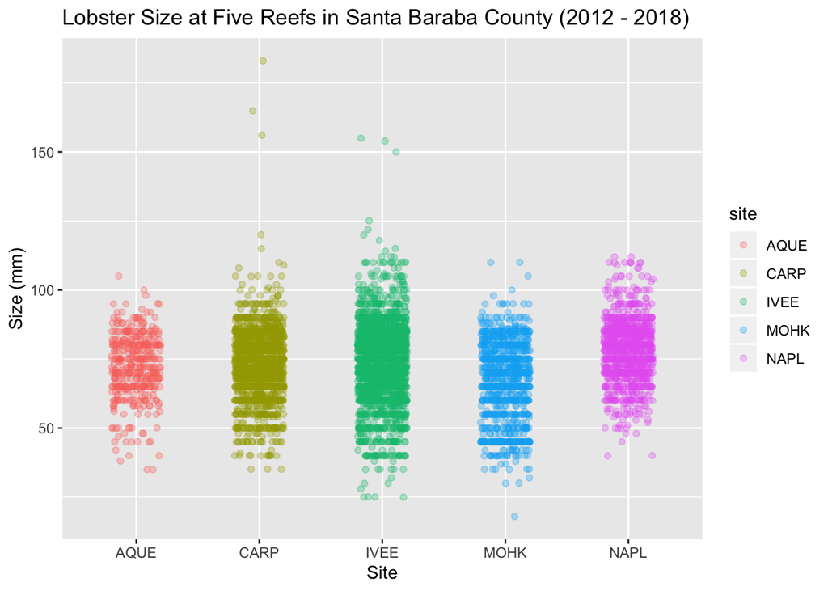

```r
# Jitterplot
ggplot(lobster_tidy, aes(x = site, y = size_mm)) +
  geom_jitter(aes(color = site),
              width = 0.2,
              alpha = 0.3) +
              labs(title = "Lobster Size at Five Reefs in Santa Baraba County (2012 - 2018)",
              x = "Site",
              y = "Size (mm)")
```

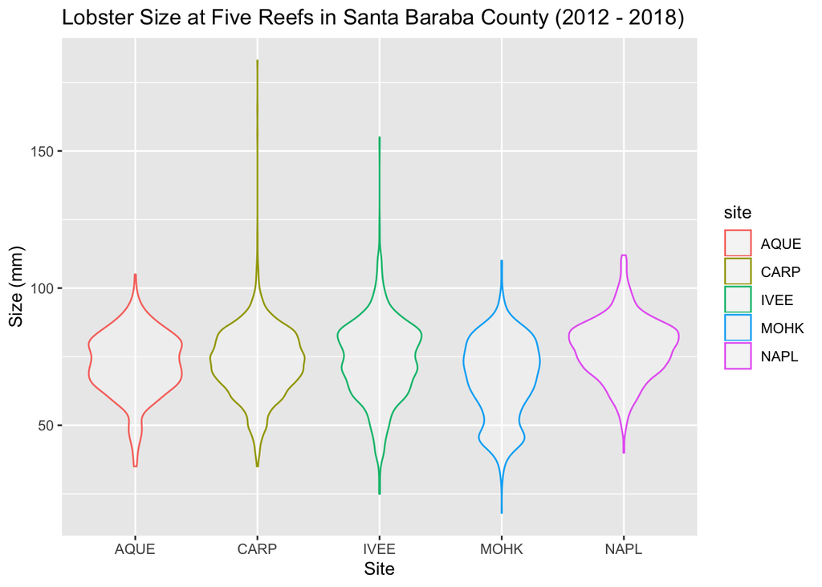

```r
ggsave(here::here("figures", "lobster_jitter.png"))
# Violin plot:
ggplot(lobster_tidy, aes(x = site, y = size_mm)) +
  geom_violin(aes(color = site), alpha = 0.3) +
              labs(title = "Lobster Size at Five Reefs in Santa Baraba County (2012 - 2018)",
              x = "Site",
              y = "Size (mm)")
```

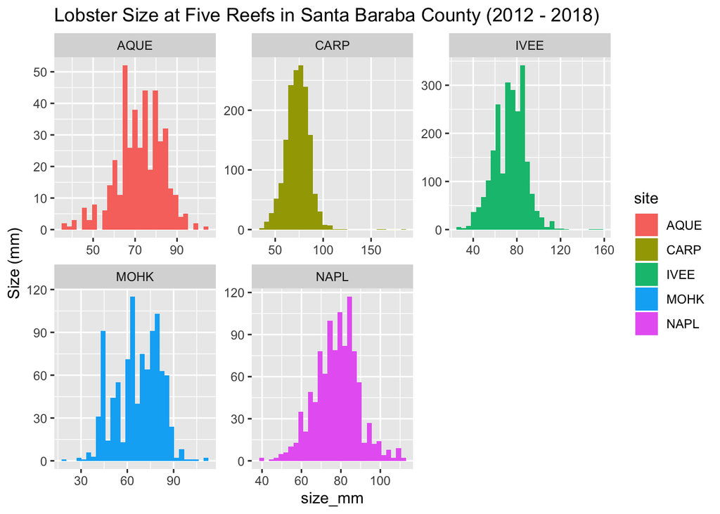

```r
ggsave(here::here("figures", "lobster_violin.png"))
# Histogram: NOTE, scale on x-axis varies making comparison accross reefs harder
ggplot(lobster_tidy, aes(x = size_mm)) +
  geom_histogram(aes(fill = site)) +
  facet_wrap(~site, scales = "free") +
              labs(title = "Lobster Size at Five Reefs in Santa Baraba County (2012 - 2018)",
              y = "Size (mm)")
```

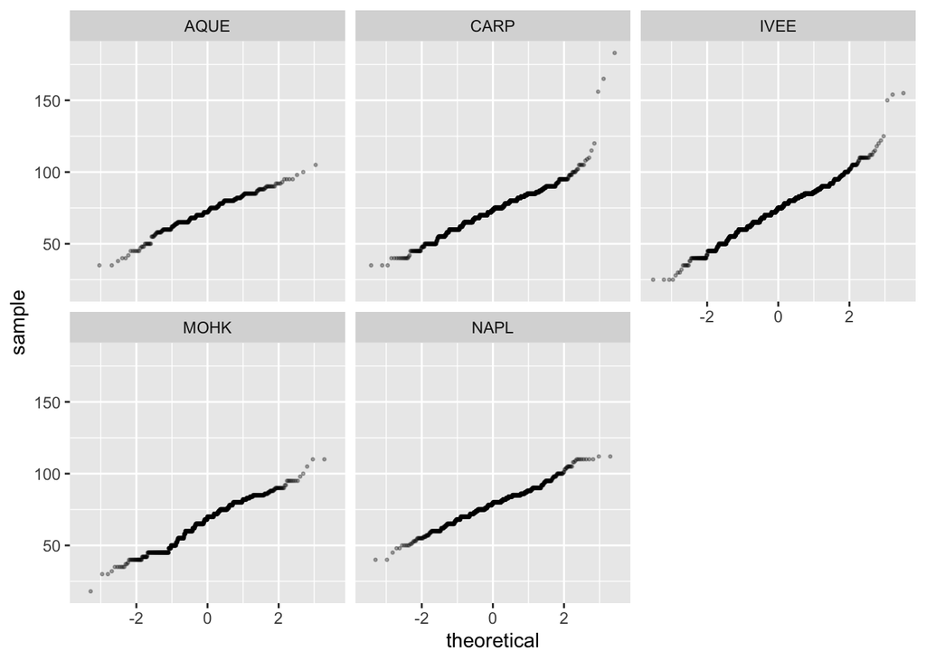

```r
ggsave(here::here("figures", "lobster_facet_hist.png"))
# Quantile-quantile plot:
ggplot(lobster_tidy, aes(sample = size_mm)) +
  geom_qq(size = 0.5, alpha = 0.3) +
  facet_wrap(~site)
```

#### 5. Parse dates for lobster observations

Notice that the existing class of the `date` variable is a character. Boo.

```r
class(lobster_abundance$date)
```

```
## [1] "character"
```

The `lubridate` package (part of the `tidyverse`), and is built to make it easier to deal with date-time data. Here, we’ll use `lubridate::mdy()` to help R understand it’s a date, and work with the pieces (month, day and year) more easily.

**Note**: we’re using `mdy()` because that’s the existing format of the date column (mm/dd/yy). Check `?ymd` to see all the different options based on the format of your date column. Cool.

Add a new column with `mutate()` that is a *date* using `mdy()`:

Check it out! The *date_new* column is in nice ISO date format. Let’s check the class:

Wooooo.

Now that it’s in date format, we can parse it. See `?month` and `?year` - to get or set components of a date or date-time. So here, we’ll use `lubridate::month()` and `lubridate::year()` to create separate columns for the month and year.

For `month()`, we can even automatically convert to month abbreviation with argument `label = TRUE`.

A really cool thing about that? When we use `lubridate::month()`, it’s auto stored as an ordered factor (so we don’t need to `fct_relevel()`).

Now let’s find some counts of lobster observations using different groupings.

#### 6. Find counts by groups with `dplyr::count()`

There are a bunch of ways to count things based on different variables in R. So many that sometimes it’s challenging to know which to use. We’ll touch on a few of the most generally useful ones here.

- `dplyr::count()`: groups, tallies, then ungroups (whoa)
- `dplyr::tally()`: use `group_by()` first, then use `tally()` for counts, then manually need to `ungroup()`
- `dplyr::n()`: number of observations in current group

##### `count()` example 1: Count the number of lobsters by year and month:

```r
# count() function does 4 things, 1) it groups by,
# 2) summarizes,
# and then 3) finds length
# and then at the end 4) ungroups data)
lobster_ym <- lobster_parse_date %>%
  count(obs_year, obs_month)

lobster_ym
```

```
## # A tibble: 8 x 3
##   obs_year obs_month     n
##      <dbl> <ord>     <int>
## 1     2012 Aug         231
## 2     2013 Aug         243
## 3     2014 Aug         404
## 4     2014 Sep         106
## 5     2015 Aug        1100
## 6     2016 Aug         809
## 7     2017 Aug        1668
## 8     2018 Aug        1805
```

##### `count()` example 2: Count the number of lobsters by year and site:

```r
lobster_ysite <- lobster_parse_date %>%
  count(obs_year, site)

lobster_ysite
```

```
## # A tibble: 35 x 3
##    obs_year site      n
##       <dbl> <chr> <int>
##  1     2012 AQUE     38
##  2     2012 CARP     78
##  3     2012 IVEE     26
##  4     2012 MOHK     83
##  5     2012 NAPL      6
##  6     2013 AQUE     32
##  7     2013 CARP     93
##  8     2013 IVEE     40
##  9     2013 MOHK     15
## 10     2013 NAPL     63
## # … with 25 more rows
```

##### `count()` example 3: Count the number of lobsters by site:

```r
lobster_site <- lobster_parse_date %>%
  count(site)

lobster_site
```

```
## # A tibble: 5 x 2
##   site      n
##   <chr> <int>
## 1 AQUE    422
## 2 CARP   1619
## 3 IVEE   2304
## 4 MOHK    982
## 5 NAPL   1039
```

##### For comparison: group first, then use `tally()` to do the same thing. Other alternatives: `add_tally()`, `add_count()` for mutate versions.

```r
lobster_tally <- lobster_parse_date %>%
  group_by(site) %>%
  tally()

lobster_tally
```

```
## # A tibble: 5 x 2
##   site      n
##   <chr> <int>
## 1 AQUE    422
## 2 CARP   1619
## 3 IVEE   2304
## 4 MOHK    982
## 5 NAPL   1039
```

What if we want to make a summary table that has a mean, sd, and the sample size? Use `dplyr::n()` to find the number of observations in the current group.

```r
lobster_summary <- lobster_parse_date %>%
  group_by(site) %>%
  summarize(
    mean_size = mean(size_mm, na.rm = TRUE),
    sd_size = sd(size_mm, na.rm = TRUE),
    sample_n = n()
  )

lobster_summary
```

```
## # A tibble: 5 x 4
##   site  mean_size sd_size sample_n
##   <chr>     <dbl>   <dbl>    <int>
## 1 AQUE       72.3    11.4      422
## 2 CARP       72.8    12.5     1619
## 3 IVEE       73.6    14.4     2304
## 4 MOHK       66.9    14.2      982
## 5 NAPL       78.2    11.1     1039
```

So, to reiterate - three ways to do the same thing to get sample sizes:

```r
lobster_n <- lobster_parse_date %>%
  group_by(site) %>%
  summarize(
    n = n()
  ) %>%
  ungroup()

lobster_tally <- lobster_parse_date %>%
  group_by(site) %>%
  tally() %>%
  ungroup()

lobster_count <- lobster_parse_date %>%
  count(site)
```

Hooray!

More information on tally/count: see descriptions and examples from [tidyverse.org](https://dplyr.tidyverse.org/reference/tally.html).

#### 7. Confidence intervals, t-tests with `t.test()`

So we found the mean and sd of lobster sizes (see object *lobster_summary*). Let’s say we want to find the confidence interval and/or standard error for lobsters at the different sites?

We can use the `t.test()` function to find confidence intervals. First, I’ll isolate the IVEE lobster lengths and find a 95% confidence interval.

```r
ivee_lobsters <- lobster_tidy %>%
  filter(site == "IVEE") %>%
  pull(size_mm)

t.test(ivee_lobsters)
```

```
##
##  One Sample t-test
##
## data:  ivee_lobsters
## t = 245.23, df = 2302, p-value < 2.2e-16
## alternative hypothesis: true mean is not equal to 0
## 95 percent confidence interval:
##  72.99130 74.16806
## sample estimates:
## mean of x
##  73.57968
```

```r
# What does this 95% CI of [72.99, 74.17] mm mean?
```

We’ve already looked at the data (jitterplots, histograms, etc.) and it seems like a t-test would be an appropriate test. Ask here: why? Sample size, distribution, data type, etc….

OK, so we’ve decided that a t-test is appropriate and useful. How do we run a t-test in R?

##### Method 1: Isolate vectors of observations, then use `t.test()`

First, we could get the vectors of observations from the two groups we want to compare, then add them as arguments to `t.test()`. Like this:

```r
# Get a vector only containing size observations (mm) for lobsters at Naples Reef (site == "NAPL"):

napl_sample <- lobster_tidy %>%
  filter(site == "NAPL") %>%
  pull(size_mm)

# Get a vector only containing size observations (mm) for lobsters at Mohawk Reef (site == "MOHK"):

mohk_sample <- lobster_tidy %>%
  filter(site == "MOHK") %>%
  pull(size_mm)
```

Check out those two objects. Note that they are *vectors* only containing size observations for lobsters at the two sites.

We can add those as our first two arguments in `t.test()` to run a two-sample t-test:

```r
mohk_napl_ttest <- t.test(mohk_sample, napl_sample)
mohk_napl_ttest
```

```
##
##  Welch Two Sample t-test
##
## data:  mohk_sample and napl_sample
## t = -19.849, df = 1850.8, p-value < 2.2e-16
## alternative hypothesis: true difference in means is not equal to 0
## 95 percent confidence interval:
##  -12.43436 -10.19806
## sample estimates:
## mean of x mean of y
##  66.86833  78.18454
```

Interpret the outcome. Now let’s say we want to write a statement about the result (for now, in very “stats class” language, which we’ll ditch quickly):

Mean lobster size differed significantly between Mohawk and Naples Reefs (t(1850.77) = -19.85, *p* < 0.001).

**Remember**: the more important things are the data itself, means comparison, effect size, etc. - which we’ll also get to.

##### Method 2: Filter to only include 2 groups, then use `t.test(A ~ B)`

```r
# First, filter to only include 2 groups (MOHK & NAPL):

lobster_2sample <- lobster_tidy %>%
  filter(site %in% c("NAPL", "MOHK"))

# Then:

ttest_2 <- t.test(size_mm ~ site, data = lobster_2sample)
```

And similarly use in-line referencing to add text directly from coded objects. Woo reproducibility!

#### 8. A new type of graph: `geom_tile()` for heatmaps

Take a look at `lobster_ysite` to remind yourself of the data frame. Let’s make a geom_tile() plot, with cell colors dependent on the value in column ‘n’.

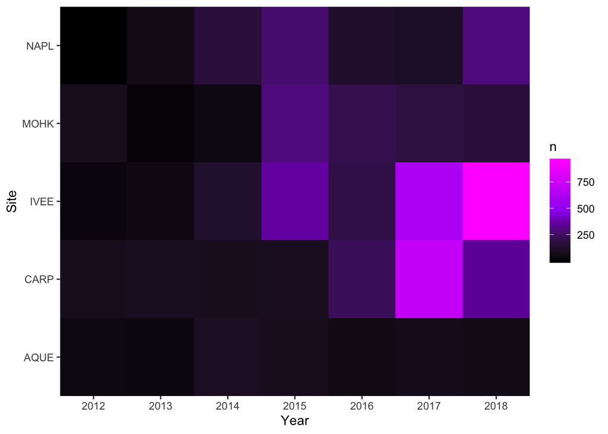

```r
ggplot(data = lobster_ysite, aes(x = obs_year, y = site)) +
  geom_tile(aes(fill = n)) +
  scale_fill_gradientn(colors = c("black","purple","magenta")) +
  scale_x_continuous(breaks = seq(2012, 2018), expand = c(0,0)) +
  scale_y_discrete(expand = c(0,0)) +
  labs(x = "Year",
       y = "Site")
```